# Lab 5 KEY

Prof. Amanda D. Perez, PhD

# Simple & Multiple Regression: Mario Kart Data

```r
library(tidyverse)
```

For this section you will be using Mario Kart Record data from TidyTuesday. See https://github.com/rfordatascience/tidytuesday/tree/master/data/2021/2021-05-25 for more detailed information about the dataset.

```r
mario <- read.csv("Data/records.csv")

glimpse(mario)
```

```
## Rows: 2,334
## Columns: 9
## $ track           <chr> "Luigi Raceway", "Luigi Raceway", "Luigi Raceway", "Lu…
## $ type            <chr> "Three Lap", "Three Lap", "Three Lap", "Three Lap", "T…
## $ shortcut        <chr> "No", "No", "No", "No", "No", "No", "No", "No", "No", …
## $ player          <chr> "Salam", "Booth", "Salam", "Salam", "Gregg G", "Rocky …
## $ system_played   <chr> "NTSC", "NTSC", "NTSC", "NTSC", "NTSC", "NTSC", "NTSC"…
## $ date            <chr> "1997-02-15", "1997-02-16", "1997-02-16", "1997-02-28"…
## $ time_period     <chr> "2M 12.99S", "2M 9.99S", "2M 8.99S", "2M 6.99S", "2M 4…
## $ time            <dbl> 132.99, 129.99, 128.99, 126.99, 124.51, 122.89, 122.87…
## $ record_duration <int> 1, 0, 12, 7, 54, 0, 0, 27, 0, 64, 3, 0, 90, 132, 1, 74…
```

# Exercise 1 -

Below we can see all 16 tracks.

```r
mario$track <- as.factor(mario$track)
levels(mario$track)
```

```
##  [1] "Banshee Boardwalk"     "Bowser's Castle"       "Choco Mountain"
##  [4] "D.K.'s Jungle Parkway" "Frappe Snowland"       "Kalimari Desert"
##  [7] "Koopa Troopa Beach"    "Luigi Raceway"         "Mario Raceway"
## [10] "Moo Moo Farm"          "Rainbow Road"          "Royal Raceway"
## [13] "Sherbet Land"          "Toad's Turnpike"       "Wario Stadium"
## [16] "Yoshi Valley"
```

I am only interested in the following tracks: Banshee Boardwalk, Bowser’s Castle, Rainbow Road, Wario Stadium, and Yoshi Valley.

Below I filter the dataset to only include data for these 5 tracks.

```r
mario <- mario %>%
  filter(track == "Banshee Boardwalk" |
           track == "Bowser's Castle" |
           track == "Yoshi Valley" |
           track == "Wario Stadium" |
           track == "Rainbow Road" )
mario$track <- droplevels(mario$track)
levels(mario$track)
```

```
## [1] "Banshee Boardwalk" "Bowser's Castle"   "Rainbow Road"
## [4] "Wario Stadium"     "Yoshi Valley"
```

Right now, `Banshee Boardwalk` is the default reference level. We know this because it is the first level that appears above. I want to change the reference level to `Bowser's Castle`. I will do that in the below code.

```r
mario$track <- relevel(mario$track, ref = "Bowser's Castle")
```

Below, I will confirm that `Bowser's Castle` is the new reference level.

```r
levels(mario$track)
```

```
## [1] "Bowser's Castle"   "Banshee Boardwalk" "Rainbow Road"
## [4] "Wario Stadium"     "Yoshi Valley"
```

`Bowser's Castle` shows up first and is now our reference level. We can now move on to our simple regression. Fill in the formula below to run a regression predicting `time` (the DV) from `track` (the IV). When you have correctly specified the `lm()` model, the `summary(mod.mario.simple)` will run without error.

```r
mod.mario.simple <- lm(time ~ track, data = mario)
summary(mod.mario.simple)
```

```
##
## Call:
## lm(formula = time ~ track, data = mario)
##
## Residuals:
##     Min      1Q  Median      3Q     Max
## -154.89  -46.01  -23.74   40.10  170.56
##
## Coefficients:
##                        Estimate Std. Error t value Pr(>|t|)
## (Intercept)              96.228      8.972  10.725  < 2e-16 ***
## trackBanshee Boardwalk    1.212     12.142   0.100 0.920486
## trackRainbow Road       109.045     10.561  10.325  < 2e-16 ***
## trackWario Stadium       35.807     10.399   3.443 0.000610 ***
## trackYoshi Valley       -40.648     10.734  -3.787 0.000166 ***
## ---
## Signif. codes:  0 '***' 0.001 '**' 0.01 '*' 0.05 '.' 0.1 ' ' 1
##
## Residual standard error: 74.53 on 687 degrees of freedom
## Multiple R-squared:  0.3499, Adjusted R-squared:  0.3462
## F-statistic: 92.46 on 4 and 687 DF,  p-value: < 2.2e-16
```

Your job is to interpret:

**The intercept** When the track is Bowser’s Castle, the time for completion is predicted to be 96.228.

**All significant slopes**

In comparison to Bowser’s Castle, Rainbow Road track takes 109.045 more time to complete. This is a significant main effect (b = 109.045, 10.56, p < 0.001).

In comparison to Bowser’s Castle, Wario Stadium track takes 35.807 more time to complete. This is a significant main effect (b = 35.807, 10.40, p < 0.001).

In comparison to Bowser’s Castle, Yoshi Valley track takes -40.648 LESS time to complete. This is a significant main effect (b = -40.648, 10.73, p < 0.001).

**The Adjusted R-Squared** Track accounts for 35% of the variance in completion time.

# Exercise 2 -

Next we will visualize the regression model. I have provided a basic graph for your below. Your job is to update the graph and: fill each bar by track, add a theme, hide the legend using `guides` argument, label the x and y axes, and add a title. Interpret what you see.

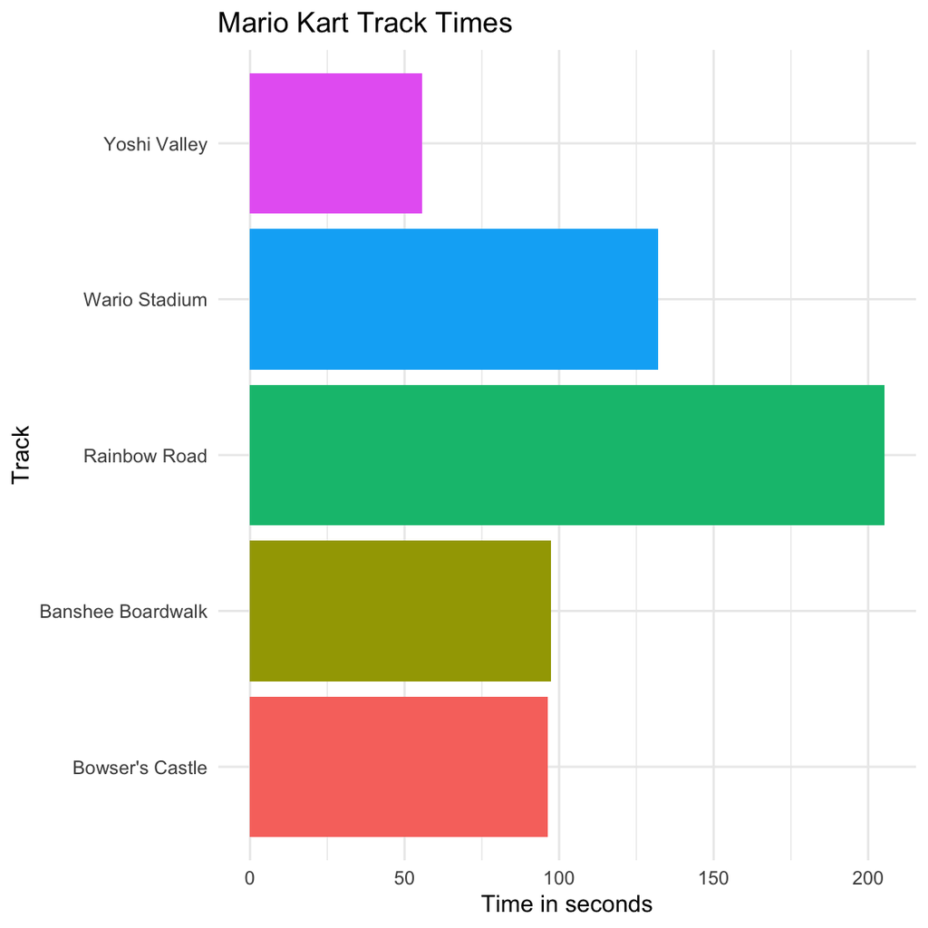

```r
ggplot(mario, aes(track, time, fill = track)) +
  stat_summary(fun = "mean", geom = "bar") +
  coord_flip() +
  labs(x = "Track", y = "Time in seconds", title = "Mario Kart Track Times") +
  guides(fill = "none") +
  theme_minimal()
```

Yoshi takes the shortest amount of time, and rainbow road takes the longest.

# Exercise 3 -

Now that we have run a simple regression (regression with just one IV) we want to now run a multiple regression. We want to run a new model that will add on a second IV: `type`

```r
mario$type <- as.factor(mario$type)
levels(mario$type)
```

```
## [1] "Single Lap" "Three Lap"
```

In this case, the reference level is `Single Lap`. I like this and will not change the reference level.

Now, it is time to build our multiple regression model. We will be predicting `time` (DV) from `track` (IV 1) AND `type` (IV 2). When you have correctly specified the `lm()` model, the `summary(mod.mario.multiple)` will run without error.

```r
mod.mario.multiple <- lm(time ~ track + type, data = mario)
summary(mod.mario.multiple)
```

```
##
## Call:
## lm(formula = time ~ track + type, data = mario)
##
## Residuals:
##      Min       1Q   Median       3Q      Max
## -203.201  -10.803   -6.815   25.745  122.249
##
## Coefficients:
##                        Estimate Std. Error t value Pr(>|t|)
## (Intercept)              33.568      6.738   4.982 7.99e-07 ***
## trackBanshee Boardwalk   -7.752      8.546  -0.907 0.364672
## trackRainbow Road       111.924      7.429  15.067  < 2e-16 ***
## trackWario Stadium       60.287      7.372   8.178 1.40e-15 ***
## trackYoshi Valley       -27.979      7.565  -3.699 0.000234 ***
## typeThree Lap           108.088      4.077  26.512  < 2e-16 ***
## ---
## Signif. codes:  0 '***' 0.001 '**' 0.01 '*' 0.05 '.' 0.1 ' ' 1
##
## Residual standard error: 52.42 on 686 degrees of freedom
## Multiple R-squared:  0.6789, Adjusted R-squared:  0.6766
## F-statistic: 290.1 on 5 and 686 DF,  p-value: < 2.2e-16
```

Your job is to interpret:

**The intercept** When the track is Bowser’s Castle AND it is single-lap, the time for completion is predicted to be 33.568.

**All significant slopes**

In comparison to Bowser’s Castle, Rainbow Road track takes 111.924 more time to complete. This is a significant main effect (b = 111.924, 7.43, p < 0.001).

In comparison to Bowser’s Castle, Wario Stadium track takes 60.287 more time to complete. This is a significant main effect (b = 60.287, 7.37, p < 0.001).

In comparison to Bowser’s Castle, Yoshi Valley track takes -27.979 LESS time to complete. This is a significant main effect (b = -27.979, 7.57, p < 0.001).

In comparison to Single Lap, Three-lap track takes 108.088 more time to complete. This is a significant main effect (b = 108.088, 4.08, p < 0.001).

**The Adjusted R-Squared** Track type and lap amount accounts for 68% of the variance in completion time.

# Exercise 4 -

Next we will visualize the multiple regression model. I have provided a basic graph for your below. Your job is to update the graph and: fill each bar by type, add a theme, and label the x and y axes, label the fill title (legend), and add a title. Interpret what you see.

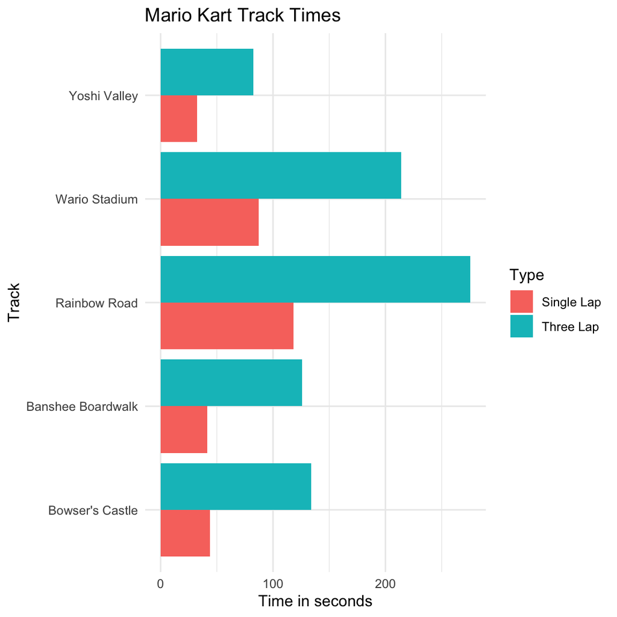

```r
ggplot(mario, aes(track, time, fill = type) )+
  stat_summary(fun = "mean", geom = "bar", position = "dodge") +
  coord_flip() +
  labs(x = "Track", y = "Time in seconds", fill = "Type", title = "Mario Kart Track Times")  +
  theme_minimal()
```

The biggest different in single versus three lap appears to be for rainbow road.

# Simple & Multiple Regression: Fishing Data

For this section you will be using Great Lakes Fishery Commission data from TidyTuesday. See https://github.com/rfordatascience/tidytuesday/tree/master/data/2021/2021-06-08 for more detailed information about the dataset.

```r
set.seed(5678)
fishing <- read_csv("Data/fishing.csv") %>%
  sample_n(8000)

glimpse(fishing)
```

```
## Rows: 8,000
## Columns: 7
## $ year        <dbl> 1962, 1905, 1932, 1984, 1956, 2007, 1924, 1867, 2005, 2004…
## $ lake        <chr> "Erie", "Huron", "Saint Clair", "Erie", "Ontario", "Erie",…
## $ species     <chr> "Lake Sturgeon", "Chubs", "Carp", "White Perch", "Amercian…
## $ grand_total <dbl> 2, NA, NA, 912, 60, 451, NA, NA, NA, 2, 1952, NA, NA, 50, …
## $ comments    <chr> NA, NA, NA, NA, NA, NA, NA, NA, NA, NA, NA, NA, "WI Totals…
## $ region      <chr> "New York (NY)", "U.S. Total (MI)", "U.S. Total (MI)", "Mi…
## $ values      <dbl> 0, 1163, NA, 0, 10, 342, NA, NA, 0, NA, 866, NA, 26833, 24…
```

# Exercise 5 -

We will be running a simple regression to predict `grand_total` from `species`. As you can see below, there are `51` different species. I am only interested in 5 different fish species: Buffalo, Crappie, Herring, White Bass, and Yellow Perch.

```r
fishing$species <- as.factor(fishing$species)
levels(fishing$species)
```

```
##  [1] "Alewife"                       "Amercian Eel"
##  [3] "American Eel"                  "Blue Pike"
##  [5] "Bowfin"                        "Buffalo"
##  [7] "Bullhead"                      "Bullheads"
##  [9] "Burbot"                        "Carp"
## [11] "Channel catfish"               "Channel Catfish"
## [13] "Channel Catfish and Bullheads" "Chinook Salmon"
## [15] "Chubs"                         "Cisco"
## [17] "Cisco and Chub"                "Cisco and chubs"
## [19] "Cisco and Chubs"               "Coho Salmon"
## [21] "Crappie"                       "Crappies"
## [23] "Drum"                          "Freshwater Drum"
## [25] "Gizzard Shad"                  "Goldfish"
## [27] "Herring"                       "Lake Sturgeon"
## [29] "Lake Trout"                    "Lake Trout - siscowet"
## [31] "Lake Whitefish"                "Minnows"
## [33] "Northern Pike"                 "Pacific salmon"
## [35] "Pacific Salmon"                "Quillback"
## [37] "Rainbow Smelt"                 "Rock Bass"
## [39] "Rock Bass and Crappie"         "Round Whitefish"
## [41] "Sauger"                        "Sheepshead"
## [43] "Smallmouth Bass"               "Suckers"
## [45] "Sunfish"                       "Walleye"
## [47] "Walleye and Blue Pike"         "White bass"
## [49] "White Bass"                    "White Perch"
## [51] "Yellow Perch"
```

Below I am filtering the data to only include these levels:

```r
fishing <- fishing %>%
  filter(species == "Buffalo" | species == "Crappie" | species == "Herring" | species == "White Bass" | species == "Yellow Perch")

fishing$species <- droplevels(fishing$species)
levels(fishing$species)
```

```
## [1] "Buffalo"      "Crappie"      "Herring"      "White Bass"   "Yellow Perch"
```

Above we see that `Buffalo` is the reference level. However, I want `White Bass` to be the reference level:

```r
fishing$species <- relevel(fishing$species, ref = "White Bass")
```

Below, I will confirm that `White Bass` is the new reference level.

```r
levels(fishing$species)
```

```
## [1] "White Bass"   "Buffalo"      "Crappie"      "Herring"      "Yellow Perch"
```

`White Bass` shows up first and is now our reference level. We can now move on to our simple regression. Fill in the formula below to run a regression predicting `grand_total` (the DV) from `species` (the IV). When you have correctly specified the `lm()` model, the `summary(mod.fish.simple)` will run without error.

```r
mod.fish.simple <- lm(grand_total ~ species, data = fishing)
summary(mod.fish.simple)
```

```
##
## Call:
## lm(formula = grand_total ~ species, data = fishing)
##
## Residuals:
##     Min      1Q  Median      3Q     Max
## -3307.1 -2620.1  -886.1   233.9 29858.9
##
## Coefficients:
##                     Estimate Std. Error t value Pr(>|t|)
## (Intercept)           1905.0      456.6   4.172 3.64e-05 ***
## speciesBuffalo       -1784.9      726.4  -2.457  0.01439 *
## speciesCrappie       -1893.3     1047.3  -1.808  0.07132 .
## speciesHerring       -1672.3     1768.4  -0.946  0.34486
## speciesYellow Perch   1402.1      538.1   2.606  0.00948 **
## ---
## Signif. codes:  0 '***' 0.001 '**' 0.01 '*' 0.05 '.' 0.1 ' ' 1
##
## Residual standard error: 4520 on 439 degrees of freedom
##   (271 observations deleted due to missingness)
## Multiple R-squared:  0.07481,    Adjusted R-squared:  0.06638
## F-statistic: 8.874 on 4 and 439 DF,  p-value: 6.747e-07
```

Your job is to interpret:

**The intercept** When the species is White Bass, the grand total is predicted to be 1905.

**All significant slopes**

In comparison to White Bass, the Buffalo species has a grand total of -1784.9 LESS. This is a significant main effect (b = -1784.9, se = 726.4, p = 0.01).

In comparison to White Bass, the Yellow Perch species has a grand total of 1402.1 MORE. This is a significant main effect (b = 1402.1, se = 538.1, p < 0.01).

**The Adjusted R-Squared** Species accounts for 7% of the variation in the grand total of fish.

# Exercise 6 -

Next we will visualize the regression model. This time, you must write your own ggplot code. Make sure you: fill each bar by species, add a theme, hide the legend using `guides` argument, label the x and y axes, and add a title. Interpret what you see.

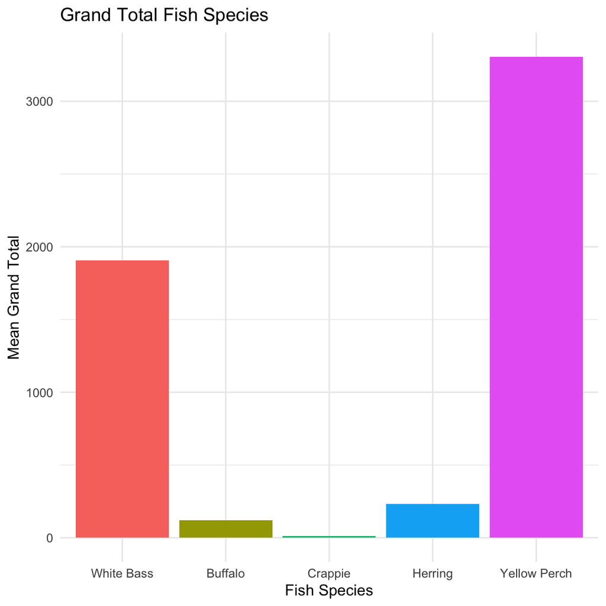

```r
ggplot(fishing, aes(species, grand_total, fill = species)) +
  stat_summary(fun = "mean", geom = "bar")  +
  labs(x = "Fish Species", y = "Mean Grand Total", title = "Grand Total Fish Species") +
  guides(fill = "none") +
  theme_minimal()
```

Crappie is the least populous fish and yellow perch is the most populous fish.

# Exercise 7 -

Now that we have run a simple regression (regression with just one IV) we want to now run a multiple regression. We want to run a new model that will add on a second IV: `lake`

```r
fishing$lake <- as.factor(fishing$lake)
levels(fishing$lake)
```

```
## [1] "Erie"        "Huron"       "Michigan"    "Ontario"     "Saint Clair"
## [6] "Superior"
```

In this case, the reference level is `Erie`. I like this and will not change the reference level.

Now, it is time to build our multiple regression model. We will be predicting `grand_total` (DV) from `species` (IV 1) AND `lake` (IV 2). When you have correctly specified the `lm()` model, the `summary(mod.fish.multiple)` will run without error. This is running an Multiple Regression Model with main effects only.

```r
mod.fish.multiple <- lm(grand_total ~ species + lake, data = fishing)
summary(mod.fish.multiple)
```

```
##
## Call:
## lm(formula = grand_total ~ species + lake, data = fishing)
##
## Residuals:
##     Min      1Q  Median      3Q     Max
## -6292.4 -1514.9  -847.3   823.3 25581.6
##
## Coefficients:
##                     Estimate Std. Error t value Pr(>|t|)
## (Intercept)           4768.8      405.0  11.776  < 2e-16 ***
## speciesBuffalo       -2020.9      579.0  -3.491 0.000531 ***
## speciesCrappie         363.0      967.1   0.375 0.707626
## speciesHerring        2169.3     1514.4   1.432 0.152722
## speciesYellow Perch   2815.6      437.2   6.440 3.17e-10 ***
## lakeHuron            -5568.1      397.3 -14.014  < 2e-16 ***
## lakeOntario          -6198.0      675.9  -9.171  < 2e-16 ***
## lakeSaint Clair      -6705.4      669.7 -10.012  < 2e-16 ***
## lakeSuperior         -7546.3      987.6  -7.641 1.39e-13 ***
## ---
## Signif. codes:  0 '***' 0.001 '**' 0.01 '*' 0.05 '.' 0.1 ' ' 1
##
## Residual standard error: 3581 on 435 degrees of freedom
##   (271 observations deleted due to missingness)
## Multiple R-squared:  0.4246, Adjusted R-squared:  0.414
## F-statistic: 40.13 on 8 and 435 DF,  p-value: < 2.2e-16
```

Your job is to interpret:

**All significant slopes (main effects only)**

In comparison to White Bass, the Buffalo species has a grand total of -2020.9 LESS. This is a significant main effect (b = -2020.9, se = 579, p < 0.01).

In comparison to White Bass, the Yellow Perch species has a grand total of 2815.6 MORE. This is a significant main effect (b = 2815.6, se = 437.2, p < 0.01).

In comparison to Lake Erie, lake Huron has a grand total of -5568.1 LESS fish. This is a significant main effect (b = -5568.1, se = 397.3, p < 0.01).

In comparison to Lake Erie, lake Ontario has a grand total of -6198.0 LESS fish. This is a significant main effect (b = -6198.0, se = 675.9, p < 0.01).

In comparison to Lake Erie, lake Saint Clair has a grand total of -6705.4 LESS fish. This is a significant main effect (b = -6705.4, se = 669.7, p < 0.01).

In comparison to Lake Erie, lake Superior has a grand total of -7546.3 LESS fish. This is a significant main effect (b = -7546.3, se = 987.6, p < 0.01).

**The Adjusted R-Squared** Fish species and lake accounts for 41% of the variance in the grand total of fish.

# Exercise 8 -

Next we will visualize the multiple regression model. This time, you must write your own ggplot code. Make sure you: make species the x axis, fill each bar by lake, add a theme, label the x and y axes, label the fill title (legend), and add a title. Interpret what you see.

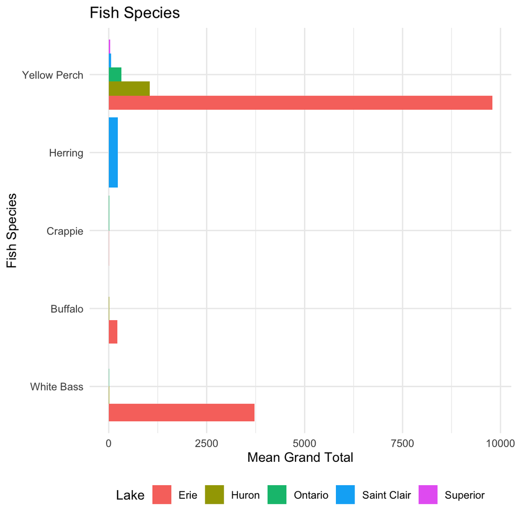

```r
ggplot(fishing, aes(species, grand_total, fill = lake) )+
  stat_summary(fun = "mean", geom = "bar", position = "dodge") +
  labs(x = "Fish Species", y = "Mean Grand Total", fill = "Lake", title = "Fish Species")  +
  theme_minimal() +
  coord_flip() +
  theme(legend.position = "bottom")
```

The yellow perch is the only fish in all of the lakes.

# Multiple Regression: Alcohol Data Interactions

```r
library(tidyverse)
```

For this section you will be using data on Alcohol Metabolism in Men and Women. These data were collected on women and men to investigate a certain theory on why women exhibit a lower tolerance for alcohol and develop alcohol–related liver disease more readily than men.

```r
alcohol <- read.csv("Data/alcohol.csv", stringsAsFactors = TRUE)
glimpse(alcohol)
```

```
## Rows: 512
## Columns: 6
## $ X       <int> 1, 2, 3, 4, 5, 6, 7, 8, 9, 10, 11, 12, 13, 14, 15, 16, 17, 18,…
## $ Subject <int> 1, 2, 3, 4, 5, 6, 7, 8, 9, 10, 11, 12, 13, 14, 15, 16, 17, 18,…
## $ Metabol <dbl> 0.6, 0.6, 1.5, 0.4, 0.1, 0.2, 0.3, 0.3, 0.4, 1.0, 1.1, 1.2, 1.…
## $ Gastric <dbl> 1.0, 1.6, 1.5, 2.2, 1.1, 1.2, 0.9, 0.8, 1.5, 0.9, 1.6, 1.7, 1.…
## $ Sex     <fct> Female, Female, Female, Female, Female, Female, Female, Female…
## $ Alcohol <fct> Alcoholic, Alcoholic, Alcoholic, Non-alcoholic, Non-alcoholic,…
```

# Exercise 9 - Cat & Num IVs interaction

We want to run a new model that used `Sex` as an independent variable.

```r
levels(alcohol$Sex)
```

```
## [1] "Female" "Male"
```

In this case, the reference level is `Female`. I like this and will not change the reference level.

Now, it is time to build our multiple regression interaction model. We will be predicting `Metabol` (DV) from `Sex` (IV 1) AND `Gastric` (IV 2). When you have correctly specified the `lm()` model, the `summary(alc.int.1)` will run without error. This is running an Multiple Regression Model with main effects AND an interaction.

`Metabol:` first–pass metabolism of alcohol in the stomach (in mmol/liter-hour)

`Gastric:` gastric alcohol dehydrogenase activity in the stomach (in µmol/min/g of tissue)

`Sex:` sex of the subject

```r
alc.int.1 <- lm(Metabol ~ Gastric*Sex, alcohol)

summary(alc.int.1)
```

```
##
## Call:
## lm(formula = Metabol ~ Gastric * Sex, data = alcohol)
##
## Residuals:
##     Min      1Q  Median      3Q     Max
## -2.4427 -0.6111 -0.0326  0.5436  3.8759
##
## Coefficients:
##                 Estimate Std. Error t value Pr(>|t|)
## (Intercept)      -0.1973     0.1883  -1.047    0.295
## Gastric           0.8369     0.1136   7.367 7.10e-13 ***
## SexMale          -0.9885     0.2518  -3.926 9.82e-05 ***
## Gastric:SexMale   1.5069     0.1313  11.480  < 2e-16 ***
## ---
## Signif. codes:  0 '***' 0.001 '**' 0.01 '*' 0.05 '.' 0.1 ' ' 1
##
## Residual standard error: 1.134 on 508 degrees of freedom
## Multiple R-squared:  0.8137, Adjusted R-squared:  0.8126
## F-statistic: 739.7 on 3 and 508 DF,  p-value: < 2.2e-16
```

Your job is to interpret:

**The intercept** When the person is female and gastric is 0, the amount of metabolism of alcohol is predicted to be -0.1973.

**All significant slopes (main effects only)**

There is a significant main effect of gastric such that for every one unit increase in gastric alcohol dehydrogenase activity, the amount of metabolism of alcohol is predicted to icrease by 0.8369, (b = 0.8369, se = 0.11, p < 0.01).

There is a significant main effect of sex such that, in comparison to females, males are predicted to have a lower amount of metabolism of alcohol by -0.9885, (b = -0.9885, se = 0.25, p < 0.01).

**Is there a significant interaction?** There is a significant interaction effect of gastric and sex and the amount of metabolism of alcohol, (b = 1.5069, se = 0.1313, p < 0.01).

**The Adjusted R-Squared** Gastric & Sex account for 81% of the variance in the amount of metabolism of alcohol.

# Exercise 10 -

Next we will visualize the multiple regression interaction model. I have provided some started code. Make sure you: set `color = Sex`, add a theme, label the x and y axes, and add a title. Interpret what you see and speak about the interaction. Is it a cross over interaction or a magnitude interaction?

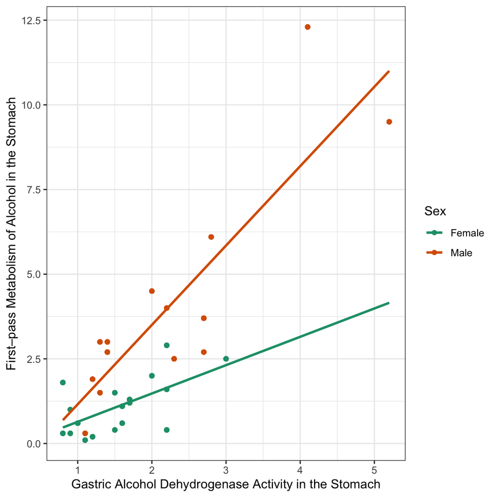

```r
ggplot(alcohol, aes(x = Gastric, y = Metabol, color = Sex)) +
  geom_point() +
  geom_smooth(method = "lm", se = FALSE, fullrange = TRUE) +
  theme_bw() +
  scale_color_brewer(palette = "Dark2") +
  labs(x = "Gastric Alcohol Dehydrogenase Activity in the Stomach", y = "First–pass Metabolism of Alcohol in the Stomach")
```

This is a magnitude interaction. When gastric is low, the difference of metabol is negligent between females and males. However, this effect increases as gastric increases such that when gastric is higher, males have much higher metabol than females.

# Multiple Regression: Temperature Data Interactions

For this section you will be using data that contains core body temperature data and gives us information about their age, weight and sex.

```r
temp <- read.csv("Data/temp2.csv", stringsAsFactors = TRUE)
glimpse(temp)
```

```
## Rows: 1,300
## Columns: 4
## $ Age         <int> 75, 60, 68, 82, 72, 18, 21, 24, 18, 21, 24, 18, 21, 24, 18…
## $ Sex         <fct> M, M, M, M, M, M, M, M, M, M, M, M, M, M, M, M, M, M, M, M…
## $ Weight      <int> 77, 83, 75, 77, 83, 75, 77, 83, 75, 77, 83, 75, 77, 83, 75…
## $ Temperature <dbl> 36.66, 36.66, 36.66, 36.66, 36.66, 36.66, 36.66, 36.66, 36…
```

# Exercise 11 -

Now, it is time to build our multiple regression interaction model. We will be predicting `Temperature` (DV) from `Age` (IV 1) AND `Weight` (IV 2). When you have correctly specified the `lm()` model, the `summary(temp.int.1)` will run without error. This is running an Multiple Regression Model with main effects AND an interaction.

```r
temp.int.1 <- lm(Temperature ~ Age*Weight, temp)

summary(temp.int.1)
```

```
##
## Call:
## lm(formula = Temperature ~ Age * Weight, data = temp)
##
## Residuals:
##      Min       1Q   Median       3Q      Max
## -0.03789 -0.01980 -0.01260  0.02390  0.09391
##
## Coefficients:
##               Estimate Std. Error  t value Pr(>|t|)
## (Intercept)  3.666e+01  1.330e-02 2756.695  < 2e-16 ***
## Age         -2.711e-03  2.531e-04  -10.709  < 2e-16 ***
## Weight      -5.785e-05  1.893e-04   -0.306     0.76
## Age:Weight   2.086e-05  3.548e-06    5.880 5.21e-09 ***
## ---
## Signif. codes:  0 '***' 0.001 '**' 0.01 '*' 0.05 '.' 0.1 ' ' 1
##
## Residual standard error: 0.02557 on 1296 degrees of freedom
## Multiple R-squared:  0.5128, Adjusted R-squared:  0.5116
## F-statistic: 454.6 on 3 and 1296 DF,  p-value: < 2.2e-16
```

Your job is to interpret:

**The intercept** When age and weight are 0, core body temperature is predicted to be 36.67.

**All significant slopes (main effects only)**

There is significant main effecr of age such that for every 1 unit increase in age, core body temp is predicted to decrease by -0.003, (b = -0.003, se = 2.531e-04, p < 0.001).

**Is there a significant interaction?** There is a significant interaction of age and weight on core body temperature, (b = .00002, se = 3.548e-06, p < 0.001).

**The Adjusted R-Squared** Age and weight accounts for 51% of the variance in core body temperature.

# Exercise 12 -

Next we will visualize the multiple regression interaction model. I have provided some started code.

Inside of the `interact_plot()` code: - set plot.points = TRUE - set x.label = “Weight (kg)” - set y.label = “Body Temp” - set legend.main = “Age”

Outside of the `interact_plot()` code: - Add a “+” (like we do with ggplot2) - Add a theme

For help, look at the lecture video and code usring `interact_plot()`.

Interpret what you see and speak about the interaction. Is it a cross over interaction or a magnitude interaction?

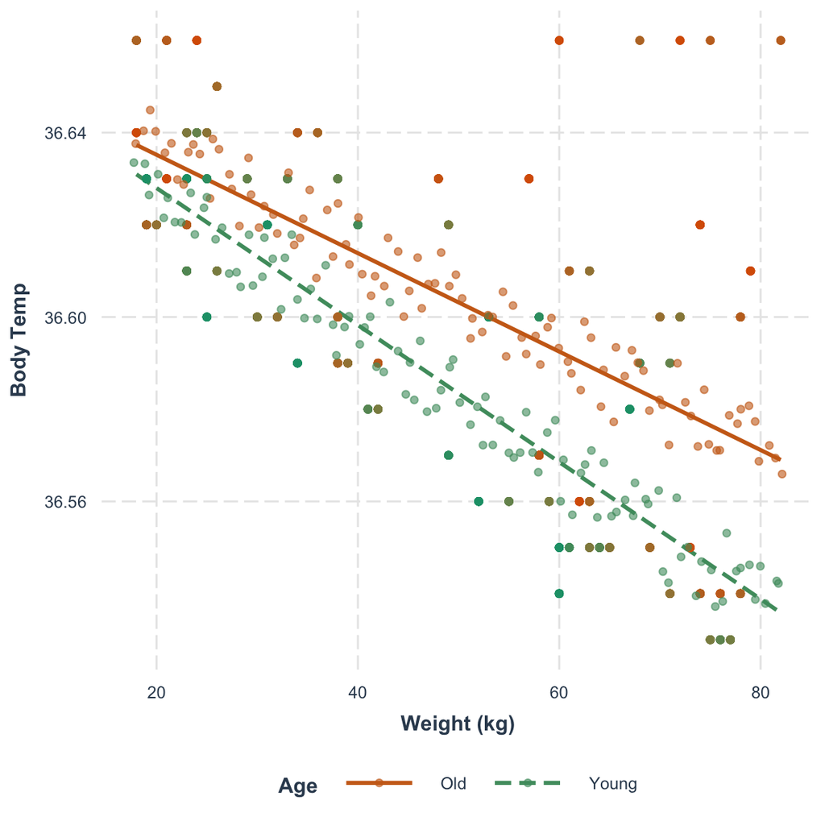

```r
library(interactions)
interact_plot(model = temp.int.1, modx = Weight,
  pred = Age, modx.values = "plus-minus",
  plot.points = TRUE, x.label = "Weight (kg)",
  y.label = "Body Temp", modx.labels = c("Young", "Old"),
  legend.main = "Age",
  colors = "Dark2") +   #Using palette from https://www.datanovia.com/en/blog/the-a-z-of-rcolorbrewer-palette/
  theme(legend.position = "bottom") +
  geom_jitter(height = 0.01, alpha = .6)
```